# Depression in married couples in Istanbul

Ilayda Dogan

2021

## Project Motivation

Whilst searching for a dataset for the ‘Data Analysis & Visualisation’ module, I was surprised by the extensive amount of data available. However, with Istanbul being my hometown, and depression being a mental disorder I have thoroughly researched, my attention was drawn to a specific dataset. Thus, I will present a visualisation of **depression scores in married couples in Istanbul and the influence of demographic factors.**

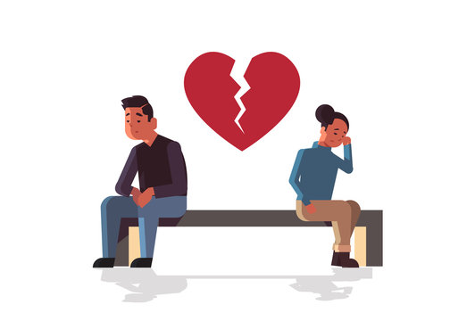

## The Data

The data is sourced from a page on [Kaggle](https://www.kaggle.com/babyoda/depression-in-married-couples). It consists of 433 data entries obtained in Istanbul via an online form. Demographic questions and a 21 question multiple choice self-report inventory, referred to as the Beck Depression Inventory (BDI), was used for data collection.

```r
#Path the data
library (here)

#Load the data
df <- read.csv(here("data", "rawdata.csv"))

#Display the data
head(df)
```

```
##    No Gender Education Working.Status Marriage.Style Status.of.Having.a.Child
## 1 345      2         4              2              2                        2
## 2  73      2         3              2              2                        1
## 3 107      2         4              2              2                        1
## 4 131      2         4              2              2                        1
## 5   4      2         4              2              1                        1
## 6 164      2         3              2              2                        1
##   B1 B2 B3 B4 B5 B6 B7 B8 B9 B10 B11 B12 B13 B14 B15 B16 B17 B18 B19 B20 B21
## 1  3  3  3  3  3  3  3  3  3   1   3   3   3   3   3   3   3   3   3   3   3
## 2  1  1  1  1  1  1  1  1  0   0   0   1   0   1   1   0   1   0   0   0   0
## 3  0  0  0  1  1  0  1  0  0   0   1   1   0   1   0   0   1   0   0   0   1
## 4  0  1  0  1  1  0  0  0  0   0   0   0   0   0   0   3   0   0   0   0   0
## 5  0  0  0  0  1  0  0  0  0   0   0   0   0   0   0   0   0   0   0   0   0
## 6  0  0  0  1  1  0  0  0  0   0   0   0   0   0   0   0   0   0   0   0   0
```

The table below provides a description of the variables used and the numbers that reflect the categories of demographic questions.

```r
# Assigning names to vectors

no <- " Survey number"
gender <- " Female (1) or Male (2)"
education <-  " Primary (1), High school (2), Bachelor (3) or Msc or phD (4)"
working_status <- "Employed (1) or Unemployed (2)"
marriage_style <- "Arranged marriage (1) or Flirt marriage/Love (2)"
status_of_having_a_child <- "Yes/Does have a child (1) or  No/ Does not have a child (2)"
bdi <- "Beck Depression Inventory, calculated by the sum of B1-B21"

#Creating a basic table

table <- data.frame(no, gender, education, working_status, marriage_style, status_of_having_a_child, bdi)

#Renaming the columns
kbl(table, col.names = c("No", "Gender", "Education", "Working status", "Marriage style", "Status of having a child", "BDI") ) %>%

#Changing the table features
kable_styling(bootstrap_options = "condensed", full_width = F,
                 html_font = "arial", font_size=13)
```

| No | Gender | Education | Working status | Marriage style | Status of having a child | BDI |
| --- | --- | --- | --- | --- | --- | --- |
| Survey number | Female (1) or Male (2) | Primary (1), High school (2), Bachelor (3) or Msc or phD (4) | Employed (1) or Unemployed (2) | Arranged marriage (1) or Flirt marriage/Love (2) | Yes/Does have a child (1) or No/ Does not have a child (2) | Beck Depression Inventory, calculated by the sum of B1-B21 |

## Research Questions

Aims of the data analysis & visualisation project:

- Was there an equal number of male and female participants that completed the online form?
- How are the BDI scores distributed? what was the average and most common score? are there any outliers present?
- Is there a relationship between education and depression?
- Is there a difference in depression scores for each qualification level based on working status?

## Data Preparation

Creating new variables, and creating and removing columns for simplification.

```r
#creating a copy of the data for modifications
copy <- read.csv(here("data", "rawdata.csv"))

#removing the non essential "No" column
copy$No <- NULL

# Defining the keys
copy$Gender [copy$Gender == 1] <- "Female"
copy$Gender [copy$Gender ==2] <- "Male"

copy$Education [copy$Education ==1] <- "Primary"
copy$Education [copy$Education ==2] <-  "High-school"
copy$Education [copy$Education ==3] <- "Bachelor"
copy$Education [copy$Education ==4] <- "Msc or phD"

copy$Working.Status [copy$Working.Status ==1] <- "Employed"
copy$Working.Status [copy$Working.Status==2] <- "Unemployed"

copy$Marriage.Style [copy$Marriage.Style ==1] <- "Arranged"
copy$Marriage.Style [copy$Marriage.Style ==2] <- "Love"

copy$Status.of.Having.a.Child [copy$Status.of.Having.a.Child == 1] <- "Yes"
copy$Status.of.Having.a.Child [copy$Status.of.Having.a.Child==2] <- "No"

#Creating a column, labelled BDI sum, containing the sum of scores
copy$BDI_score <-  rowSums(copy[1:433,6:26])

#Removing the individual scores
copy <- copy[, -c(6:26)]

#displaying the modified dataset
head(copy)
```

```
##   Gender  Education Working.Status Marriage.Style Status.of.Having.a.Child
## 1   Male Msc or phD     Unemployed           Love                       No
## 2   Male   Bachelor     Unemployed           Love                      Yes
## 3   Male Msc or phD     Unemployed           Love                      Yes
## 4   Male Msc or phD     Unemployed           Love                      Yes
## 5   Male Msc or phD     Unemployed       Arranged                      Yes
## 6   Male   Bachelor     Unemployed           Love                      Yes
##   BDI_score
## 1        61
## 2        12
## 3         8
## 4         6
## 5         1
## 6         2
```

## Total gender from online form: Visualisation 1.

Initially, i wanted to determine the number of males and females that participated in this study, as depression is more prevalent in women (Albert,2015), thus, it is a factor that should be controlled for when studying other demographic factors.

```r
#Data preparation- Creating a new dataframe containing the count of each gender
pie<-  copy %>%
  group_by(Gender) %>%
   summarize(counts = n())
```

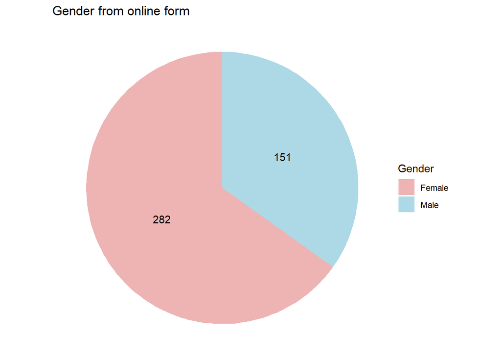

```r
#Creating a pie chart to display the proportion of each gender in the study

#Creating a basic bar
piechart <- ggplot(data = pie, aes(x="", y= counts, fill = Gender)) + geom_bar(stat="identity") +
  #Converting to pie
  coord_polar("y", start=0 ) +
  #Adding labels and changing their position
  geom_text(aes(label= counts), position = position_stack(vjust = 0.5)) +
  #Adding a title
  labs(title= "Gender from online form") +
  #Removing the axis and background
  theme_void() +
  #Changing the colours
  scale_fill_manual(values = c("rosybrown2", "lightblue"))

#Displaying the visualisation
piechart
```

```r
#Saving the visualisation
ggsave ("piechart.png")
```

**Aim 1:** *Was there an equal number of male and female participants that completed the online form?*

## BDI distribution: Visualisation 2.

Next, i wanted to utilise a histogram to display an overview of the BDI scores obtained in the study, before searching for any potential relationships between demographic factors and depression.

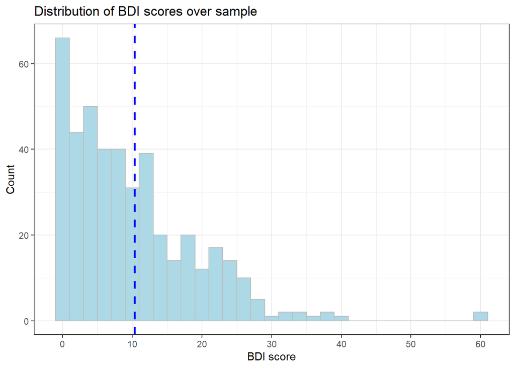

```r
dist <- ggplot(copy,
       aes(x=BDI_score)) +
  #Changing the binwidth and colour of the bars
  geom_histogram(binwidth=2, colour= "grey", fill ="lightblue") +
  #Adjusting the X axis to specify limits and where the tick marks appear
  scale_x_continuous(breaks= seq(0,65,10)) +
  #Adding a mean line
  geom_vline(aes(xintercept=mean(BDI_score)),
        color="blue", linetype="dashed", size=1) +
  #Adding a title and labelling the axis
  labs(title = "Distribution of BDI scores over sample",
                              x = "BDI score", y= "Count") +
  #Changing the size of the text
  theme(text = element_text(size=13)) +
  #Changing the plot theme
  theme_bw()

#Displaying the visualisation
dist
```

```r
#Saving the visualisation
ggsave ("dist.png")
```

**Aim 2** *: How are the BDI scores distributed amongst the 433 participants? What is the mode and the mean and are there any outliers?*

Observations from the BDI distribution

- Most people had a BDI score of 0, suggesting that they were not depressed, and there is an overall reduction in the count of the participants as the BDI scores increase.
- The average BDI score was ≈10.
- There are individuals with a particularly high BDI scores of ≈60.

Such conclusions can be confirmed through analysis of the data.

```r
#Determining the most frequent score
x <- copy$BDI_score
Mode <- function(x) {
  ux <- unique(x)
  ux[which.max(tabulate(match(x, ux)))]
}
mode <- Mode(x)

#Determining the average score
mean <- mean(copy$BDI_score)

#Determining the maximum score
outlier <- max(copy$BDI_score, na.rm=T)

#Creating a summary table containing the results
summary <- data.frame(mode,mean,outlier)

#Defining the type of table and inserting column names
knitr::kable(summary, "pipe", col.names =c("Most common score", "Average score", "Outlier score"),
#Specifying number of digits displayed
digits=2,
#Alligning to the left
align = "l")
```

| Most common score | Average score | Outlier score |
| --- | --- | --- |
| 0 | 10.34 | 61 |

# Qualification level and depression: Visualisation 3.

After obtaining an overview of the BDI scores, i wanted to focus on whether education could be a demographic factor that influenced depression.

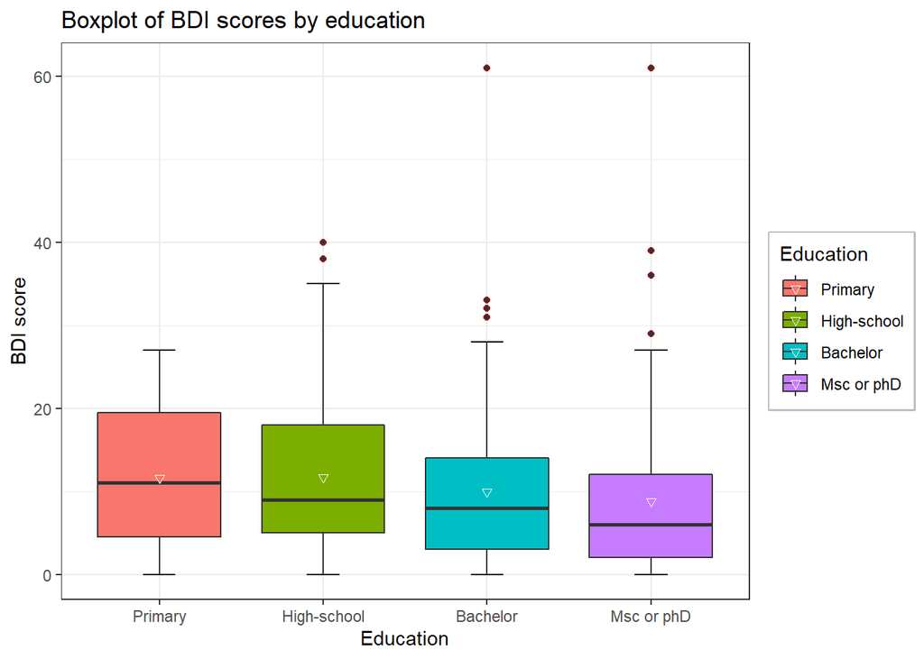

```r
#Creating a new dataframe containing the columns of interest
df2 <-copy %>%
  select(Education, BDI_score)

# Specifying the order of the qualification levels
df2$Education <- factor(df2$Education,levels = c("Primary", "High-school", "Bachelor",  "Msc or phD"))

#Creating a box plot of Education and BDI score
boxplot <- ggplot(df2,
                  aes(x=BDI_score, y=Education, fill =Education)) +
                     stat_boxplot() +
# Adjusting the X axis to specify limits and where the tick marks appear
scale_x_continuous( breaks =seq(0, 65, 20)) +
  #Rotating the boxplot
  coord_flip() +
  #Adding error bars and changing the width
  stat_boxplot(geom ='errorbar', width = 0.2) +
  #Changing the outlier colour and shape
  geom_boxplot(outlier.colour = "red", outlier.shape = 1) +
  #Displaying the mean
  stat_summary(fun="mean", geom ="point", shape= 25, color="white") +
  #Adding a title and labelling the axis
  labs(title = "Boxplot of BDI scores by education", x = "BDI score",
       y= "Education") +
  #Changing the size of the text
  theme(text = element_text(size=13)) +
  #Changing the theme
  theme_bw() +
  #Creating a custom box around the legend
  theme(legend.box.background = element_rect(color="grey", size=1))

#Displaying the visualisation
boxplot
```

```r
#Saving the visualisation
ggsave ("boxplot.png")
```

**Aim 3:** *Could education be a demographic factor that influences depression*

Observations from the boxplot

- By comparing the mean, it can be suggested that the more education you are, the less depressed you are, as there was a decrease in the average BDI score with the smallest belonging to the MSc/PhD group, however, the primary category did not fit this pattern.
- Comparing the median also suggests that highly educated individuals tend to be less depressed, however, there are exceptions, as the two outliers with a high BDI score of 61 belong to those with a Bachelors and and a Msc or phD.

# Depression, working status and qualification level: Visualisation 4.

From visualisation 3, higher qualifications seemed to be associated with lower BDI scores. It seems plausible that highly educated individuals are in better paid jobs, thus have better living standards and less depression. This final visualisation will thus focus on each qualification level and attempt to determine if working status could influence this.

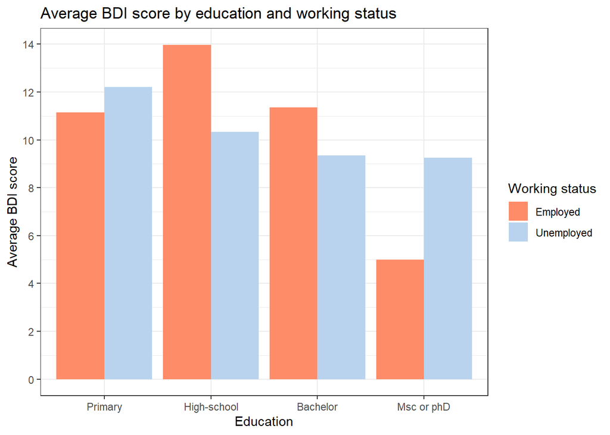

```r
#Creating a new data frame that contains the average BDI score of those that are employed and unemployed in each educational category by grouping working status nad education
df3 <- copy %>%
  group_by(Working.Status, Education) %>%
  summarise(average = mean(BDI_score))

#Determining the order of qualification
df3$Education <- factor(df3$Education,levels = c("Primary", "High-school", "Bachelor",  "Msc or phD"))

#Creating a bar graph
barplot <- ggplot(df3, aes(x = Education, y = average,
                fill = Working.Status)) + geom_col(position = "dodge") +
  #Determining y axis limits and where tick marks appear
  scale_y_continuous(breaks=seq(0,16, 2)) +
  #Changing the colour of the bars
  scale_fill_manual(values = c("salmon1", "slategray2")) +
  #Adding a title and changing the axis and legend label
  labs(title = "Average BDI score by education and working status",
          x= "Education", y= "Average BDI score",
          fill ="Working status") +
  #Changing the size of the text
  theme(text = element_text(size=13)) +
  #Changing the plot theme
  theme_bw()

#displaying the visualisation
barplot
```

```r
#saving the visualisation
ggsave("barplot.png")
```

*Aim 4:* **Is there a difference in the BDI scores for each qualification level based on working status?**

Observations from the barplot

- The average BDI score seems to be higher among those that are employed in comparison to those that are unemployed for high school and bachelor graduates, but lower for employed individuals that are primary and Msc/phD graduates, thus, a clear relationship cannot be established.
- However, when focusing on the lowest BDI score, it belongs to Msc or phD graduates that are employed, which suggests that the previous hypothesis could be true.

# Summary

An important conclusion to make from these visualisations is that it is difficult to establish a clear, causal relationship between depression and demographic factors. It seems flawed to pinpoint a single factor and associate it with such a complex mental disorder. Additionally, there are numerous limitations associated with this study which will be outlined below.

- There was an unequal number of males and females, as evident in visualisation one. Thus, when seeking to find a relationship between other demographic factors and depression, gender could have been a confound.
- There are factors that were not considered, such as age, which could also act as an confounding variable, as depression is known to be highest among those aged 18–29 (Villarroel, 2020).

Despite this, the study utilised a large sample size, which was beneficial in minimising the margin of error and allowing the identification of outliers and more accurate mean values. Additionally, the use of an online form and anonymising the data by not providing participant name and surname increases the likelihood of obtaining more accurate answers, therefore, the results can be used by other researchers in the future.

# Future Pursuits

Due to the time constraints of the module, there were variables that were not directly studied, for instance, the relationship between marriage style and BDI score. Additionally, there were factors that were not controlled for. The basis of future projects thus could be the examination of other untouched demographic factors and its correlation to the average BDI score, and the control of factors when looking for a causal relationship.

# References

Albert P. R. (2015). Why is depression more prevalent in women?. Journal of psychiatry & neuroscience : JPN, 40(4), 219–221. https://doi.org/10.1503/jpn.150205

Villarroel, M. A., & Terlizzi, E. P. (2020). Symptoms of Depression Among Adults: United States, 2019. NCHS data brief, (379), 1–8.